# Avaliação Continuada - Aula 3

### Base de Dados - Turma B

Os exercícios de avaliação continuada da **Turma B** serão realizados com a base de dados de passageiros da embarcação Titanic, chamada de `titanic`. Essa é uma base de dados que é disponibilizada como dados de exemplo pela própria biblioteca `seaborn`, por meio da função `load_dataset`. Execute a célula a seguir para importar as bibliotecas de que vamos precisar e criar a variável `titanic` com nossa base de dados.

```python
# Importando a biblioteca seaborn
import seaborn as sns

# Carregando a base de dados 'taxis'
titanic = sns.load_dataset("titanic")

titanic.head()
```

|  | survived | pclass | sex | age | sibsp | parch | fare | embarked | class | who | adult_male | deck | embark_town | alive | alone |
| --- | --- | --- | --- | --- | --- | --- | --- | --- | --- | --- | --- | --- | --- | --- | --- |
| 0 | 0 | 3 | male | 22.0 | 1 | 0 | 7.2500 | S | Third | man | True | NaN | Southampton | no | False |
| 1 | 1 | 1 | female | 38.0 | 1 | 0 | 71.2833 | C | First | woman | False | C | Cherbourg | yes | False |
| 2 | 1 | 3 | female | 26.0 | 0 | 0 | 7.9250 | S | Third | woman | False | NaN | Southampton | yes | True |
| 3 | 1 | 1 | female | 35.0 | 1 | 0 | 53.1000 | S | First | woman | False | C | Southampton | yes | False |
| 4 | 0 | 3 | male | 35.0 | 0 | 0 | 8.0500 | S | Third | man | True | NaN | Southampton | no | True |

### Sobre os dados

A base `titanic` contém informações sobre 891 passageiros do Titanic (unidade de observação). A base contém 15 variáveis (colunas), incluindo o sexo e a idade do passageiro, se ele sobreviveu ou não ao naufrágio, o preço pago pela viagem, a classe em que ele estava situado (Primeira Classe, Segunda Classe ou Terceira Classe), dentre outras informações.

No exercício de hoje, vamos utilizar as variáveis:

1. `embark_town`, referente à cidade de partida, na qual o passageiro embarcou no Titanic;
2. `fare`, referente ao valor da passagem paga pelo passageiro;

Queremos verificar se o valor médio da passagem varia de acordo com o local no qual a pessoa embarcou no navio.

### Exercício de hoje

Utilize a função `sns.barplot()` para criar um gráfico de barras que mostra o valor médio da passagem (coluna `"fare"`) pago pelos passegeiros do titanic, de acordo com o local no qual eles embarcaram (`embark_town`).

Escolha também uma cor para seu gráfico, diferente da cor padrão. Consulte a lista de cores nomeadas abaixo:

[figure not shown]

Após escrever a linha de código de sua resposta, execute a célula para mostrar o gráfico a partir da base `titanic`.

**Importante: antes de executar o código da sua resposta, não deixe de executar a célula de código que está no início deste caderno, que importa as bibliotecas e carrega os dados.**

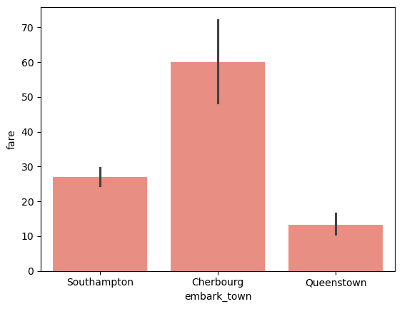

```python
## Escreva sua resposta abaixo e execute a célula para gerar o gráfico
sns.barplot(
    x="embark_town",
    y="fare",
    color="salmon", # Aqui poderia ser qualquer cor
    data=titanic
)
```

### Exercício - Parte 2

Copie o código do gráfico anterior.

Agora você deve remover a barra de erro do gráfico, que é exibida por padrão. Para isso, utilize o argumento `errorbar` com o valor `None`.

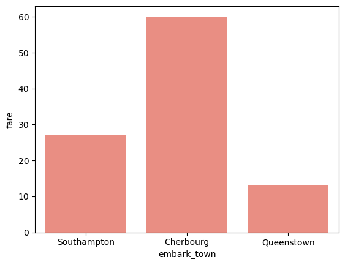

```python
## Escreva sua resposta abaixo e execute a célula para gerar o gráfico
sns.barplot(
    x="embark_town",
    y="fare",
    color="salmon", # Aqui poderia ser qualquer cor
    errorbar=None,
    data=titanic
)
```